# Laboratorio 4.1: Distancias y Medidas de Similitud

## 1.3 Visualización de Matrices de Distancia

### Ejercicio 1.5: Heatmap de distancias

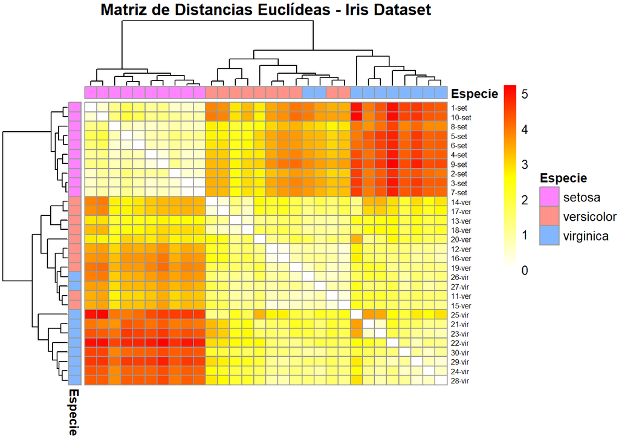

```r
# Seleccionar una muestra del dataset iris
set.seed(42)
sample_idx <- c(
  sample(which(iris$Species == "setosa"), 10),
  sample(which(iris$Species == "versicolor"), 10),
  sample(which(iris$Species == "virginica"), 10)
)
iris_sample <- iris[sample_idx, ]
X_sample <- iris_sample[, 1:4]

# Calcular matriz de distancias (estandarizada - ver Ejercicio 1.4)
dist_matrix <- dist(scale(X_sample), method = "euclidean")
dist_mat <- as.matrix(dist_matrix)

# Crear etiquetas con especies
row_labels <- paste0(1:30, "-", substr(iris_sample$Species, 1, 3))
rownames(dist_mat) <- row_labels
colnames(dist_mat) <- row_labels

# Crear anotación de especies
annotation_row <- data.frame(
  Especie = iris_sample$Species
)
rownames(annotation_row) <- row_labels

# Heatmap con clustering jerárquico
# NOTA: pheatmap aplica clustering jerárquico por defecto para reordenar
# las observaciones y agrupar las más similares. Esto facilita la visualización.
pheatmap(dist_mat,
         color = colorRampPalette(c("white", "yellow", "red"))(100),
         annotation_row = annotation_row,
         annotation_col = annotation_row,
         show_rownames = TRUE,
         show_colnames = FALSE,
         main = "Matriz de Distancias Euclídeas - Iris Dataset",
         fontsize_row = 6,
         clustering_distance_rows = "euclidean",
         clustering_distance_cols = "euclidean",
         clustering_method = "complete")
```

```r
cat("\nInterpretación del heatmap:\n")
```

```
Interpretación del heatmap:
```

```r
cat("- Colores claros (amarillo/blanco) → Distancias pequeñas (observaciones similares)\n")
```

```
- Colores claros (amarillo/blanco) → Distancias pequeñas (observaciones similares)
```

```r
cat("- Colores oscuros (rojo) → Distancias grandes (observaciones diferentes)\n")
```

```
- Colores oscuros (rojo) → Distancias grandes (observaciones diferentes)
```

```r
cat("- Las filas/columnas están REORDENADAS por clustering jerárquico\n")
```

```
- Las filas/columnas están REORDENADAS por clustering jerárquico
```

```r
cat("- Los bloques en la diagonal principal muestran que las observaciones\n")
```

```
- Los bloques en la diagonal principal muestran que las observaciones
```

```r
cat("  de la misma especie tienden a ser más similares entre sí\n")
```

```
  de la misma especie tienden a ser más similares entre sí
```

```r
cat("- El dendrograma lateral muestra la jerarquía de agrupamiento\n")
```

```
- El dendrograma lateral muestra la jerarquía de agrupamiento
```

# Parte 2: Distancias para Datos Binarios

## 2.1 Distancias Binarias

### Ejercicio 2.1: Coeficientes de similitud para datos binarios

**Objetivo**: Calcular y comparar diferentes medidas de similitud binaria.

```r
# Ejemplo: Presencia/ausencia de síntomas en pacientes
# 1 = presente, 0 = ausente
paciente_A <- c(1, 1, 0, 1, 0, 0, 1, 1)
paciente_B <- c(1, 1, 1, 0, 0, 0, 1, 0)
paciente_C <- c(0, 0, 0, 0, 1, 1, 0, 0)

sintomas <- c("Fiebre", "Tos", "Dolor_cabeza", "Fatiga",
              "Náuseas", "Mareos", "Dolor_garganta", "Congestión")

cat("=== DATOS BINARIOS: PRESENCIA DE SÍNTOMAS ===\n\n")
```

```
=== DATOS BINARIOS: PRESENCIA DE SÍNTOMAS ===
```

```r
sintomas_df <- data.frame(
  Síntoma = sintomas,
  Paciente_A = paciente_A,
  Paciente_B = paciente_B,
  Paciente_C = paciente_C
)
print(sintomas_df)
```

```
         Síntoma Paciente_A Paciente_B Paciente_C
1         Fiebre          1          1          0
2            Tos          1          1          0
3   Dolor_cabeza          0          1          0
4         Fatiga          1          0          0
5        Náuseas          0          0          1
6         Mareos          0          0          1
7 Dolor_garganta          1          1          0
8     Congestión          1          0          0
```

```r
# Función para calcular tabla de contingencia 2x2
tabla_2x2 <- function(x, y) {
  a <- sum(x == 1 & y == 1)  # Ambos tienen el atributo
  b <- sum(x == 1 & y == 0)  # Solo x tiene el atributo
  c <- sum(x == 0 & y == 1)  # Solo y tiene el atributo
  d <- sum(x == 0 & y == 0)  # Ninguno tiene el atributo
  return(c(a = a, b = b, c = c, d = d))
}

# Calcular tablas 2x2
cat("\n=== TABLAS DE CONTINGENCIA 2x2 ===\n\n")
```

```
=== TABLAS DE CONTINGENCIA 2x2 ===
```

```r
tab_AB <- tabla_2x2(paciente_A, paciente_B)
cat("Paciente A vs Paciente B:\n")
```

```
Paciente A vs Paciente B:
```

```r
cat(sprintf("  a (1,1): %d  |  b (1,0): %d\n", tab_AB["a"], tab_AB["b"]))
```

```
  a (1,1): 3  |  b (1,0): 2
```

```r
cat(sprintf("  c (0,1): %d  |  d (0,0): %d\n\n", tab_AB["c"], tab_AB["d"]))
```

```
  c (0,1): 1  |  d (0,0): 2
```

```r
tab_AC <- tabla_2x2(paciente_A, paciente_C)
cat("Paciente A vs Paciente C:\n")
```

```
Paciente A vs Paciente C:
```

```r
cat(sprintf("  a (1,1): %d  |  b (1,0): %d\n", tab_AC["a"], tab_AC["b"]))
```

```
  a (1,1): 0  |  b (1,0): 5
```

```r
cat(sprintf("  c (0,1): %d  |  d (0,0): %d\n\n", tab_AC["c"], tab_AC["d"]))
```

```
  c (0,1): 2  |  d (0,0): 1
```

```r
# Calcular diferentes coeficientes de similitud
coef_jaccard <- function(x, y) {
  tab <- tabla_2x2(x, y)
  tab["a"] / (tab["a"] + tab["b"] + tab["c"])
}

coef_simple_matching <- function(x, y) {
  tab <- tabla_2x2(x, y)
  (tab["a"] + tab["d"]) / sum(tab)
}

coef_dice <- function(x, y) {
  tab <- tabla_2x2(x, y)
  (2 * tab["a"]) / (2 * tab["a"] + tab["b"] + tab["c"])
}

coef_rogers_tanimoto <- function(x, y) {
  tab <- tabla_2x2(x, y)
  (tab["a"] + tab["d"]) / (tab["a"] + 2*(tab["b"] + tab["c"]) + tab["d"])
}

cat("=== COEFICIENTES DE SIMILITUD ===\n\n")
```

```
=== COEFICIENTES DE SIMILITUD ===
```

```r
# A vs B
cat("Paciente A vs Paciente B:\n")
```

```
Paciente A vs Paciente B:
```

```r
cat(sprintf("  Jaccard:           %.4f\n", coef_jaccard(paciente_A, paciente_B)))
```

```
  Jaccard:           0.5000
```

```r
cat(sprintf("  Simple Matching:   %.4f\n", coef_simple_matching(paciente_A, paciente_B)))
```

```
  Simple Matching:   0.6250
```

```r
cat(sprintf("  Dice:              %.4f\n", coef_dice(paciente_A, paciente_B)))
```

```
  Dice:              0.6667
```

```r
cat(sprintf("  Rogers-Tanimoto:   %.4f\n\n", coef_rogers_tanimoto(paciente_A, paciente_B)))
```

```
  Rogers-Tanimoto:   0.4545
```

```r
# A vs C
cat("Paciente A vs Paciente C:\n")
```

```
Paciente A vs Paciente C:
```

```r
cat(sprintf("  Jaccard:           %.4f\n", coef_jaccard(paciente_A, paciente_C)))
```

```
  Jaccard:           0.0000
```

```r
cat(sprintf("  Simple Matching:   %.4f\n", coef_simple_matching(paciente_A, paciente_C)))
```

```
  Simple Matching:   0.1250
```

```r
cat(sprintf("  Dice:              %.4f\n", coef_dice(paciente_A, paciente_C)))
```

```
  Dice:              0.0000
```

```r
cat(sprintf("  Rogers-Tanimoto:   %.4f\n\n", coef_rogers_tanimoto(paciente_A, paciente_C)))
```

```
  Rogers-Tanimoto:   0.0667
```

```r
cat("=== INTERPRETACIÓN ===\n")
```

```
=== INTERPRETACIÓN ===
```

```r
cat("\nCoeficiente de Jaccard:\n")
```

```
Coeficiente de Jaccard:
```

```r
cat("- Solo considera coincidencias positivas (1,1)\n")
```

```
- Solo considera coincidencias positivas (1,1)
```

```r
cat("- Ignora las ausencias conjuntas (0,0)\n")
```

```
- Ignora las ausencias conjuntas (0,0)
```

```r
cat("- Útil cuando la ausencia no es informativa\n")
```

```
- Útil cuando la ausencia no es informativa
```

```r
cat("\nSimple Matching:\n")
```

```
Simple Matching:
```

```r
cat("- Considera tanto coincidencias positivas (1,1) como negativas (0,0)\n")
```

```
- Considera tanto coincidencias positivas (1,1) como negativas (0,0)
```

```r
cat("- Útil cuando las ausencias son tan informativas como las presencias\n")
```

```
- Útil cuando las ausencias son tan informativas como las presencias
```

```r
cat("\nCoeficiente de Dice:\n")
```

```
Coeficiente de Dice:
```

```r
cat("- Similar a Jaccard pero da doble peso a las coincidencias positivas\n")
```

```
- Similar a Jaccard pero da doble peso a las coincidencias positivas
```

```r
cat("\nRogers-Tanimoto:\n")
```

```
Rogers-Tanimoto:
```

```r
cat("- Penaliza más las discordancias que Simple Matching\n")
```

```
- Penaliza más las discordancias que Simple Matching
```

```r
# Convertir similitud a distancia
cat("\n=== CONVERSIÓN A DISTANCIA ===\n")
```

```
=== CONVERSIÓN A DISTANCIA ===
```

```r
cat("Distancia = 1 - Similitud\n\n")
```

```
Distancia = 1 - Similitud
```

```r
cat("Distancias (Jaccard) A-B y A-C:\n")
```

```
Distancias (Jaccard) A-B y A-C:
```

```r
cat(sprintf("  d(A,B) = %.4f\n", 1 - coef_jaccard(paciente_A, paciente_B)))
```

```
  d(A,B) = 0.5000
```

```r
cat(sprintf("  d(A,C) = %.4f\n", 1 - coef_jaccard(paciente_A, paciente_C)))
```

```
  d(A,C) = 1.0000
```

```r
cat("\nInterpretación: El paciente C es más diferente de A que el paciente B\n")
```

```
Interpretación: El paciente C es más diferente de A que el paciente B
```

**Pregunta 5**: ¿Cuándo usarías Jaccard en lugar de Simple Matching?

### Ejercicio 2.2: Aplicación con dataset real

```r
# Crear dataset binario de ejemplo: características de películas
set.seed(123)
peliculas <- data.frame(
  Accion = c(1, 1, 0, 0, 1, 0, 1, 1),
  Comedia = c(0, 1, 1, 1, 0, 1, 0, 0),
  Drama = c(0, 0, 1, 1, 0, 1, 1, 0),
  Sci_Fi = c(1, 1, 0, 0, 1, 0, 1, 1),
  Romance = c(0, 1, 1, 0, 0, 1, 0, 0),
  Thriller = c(1, 0, 0, 1, 1, 0, 1, 1)
)
rownames(peliculas) <- paste("Pelicula", 1:8)

cat("=== GÉNEROS DE PELÍCULAS (1=presente, 0=ausente) ===\n")
```

```
=== GÉNEROS DE PELÍCULAS (1=presente, 0=ausente) ===
```

```r
print(peliculas)
```

```
           Accion Comedia Drama Sci_Fi Romance Thriller
Pelicula 1      1       0     0      1       0        1
Pelicula 2      1       1     0      1       1        0
Pelicula 3      0       1     1      0       1        0
Pelicula 4      0       1     1      0       0        1
Pelicula 5      1       0     0      1       0        1
Pelicula 6      0       1     1      0       1        0
Pelicula 7      1       0     1      1       0        1
Pelicula 8      1       0     0      1       0        1
```

```r
# Calcular distancias con Jaccard verdadero usando proxy
cat("\nNOTA: Usamos proxy::dist() con method='Jaccard' para calcular\n")
```

```
NOTA: Usamos proxy::dist() con method='Jaccard' para calcular
```

```r
cat("la distancia de Jaccard correcta. dist() con method='binary'\n")
```

```
la distancia de Jaccard correcta. dist() con method='binary'
```

```r
cat("calcula una métrica binaria diferente.\n\n")
```

```
calcula una métrica binaria diferente.
```

```r
# Cargar proxy si no está cargado
if (!require("proxy", quietly = TRUE)) {
  install.packages("proxy")
  library(proxy)
}

# Calcular distancia de Jaccard correcta
dist_jaccard <- proxy::dist(peliculas, method = "Jaccard", by_rows = TRUE)

cat("=== MATRIZ DE DISTANCIAS (Jaccard) ===\n")
```

```
=== MATRIZ DE DISTANCIAS (Jaccard) ===
```

```r
print(round(as.matrix(dist_jaccard), 3))
```

```
           Pelicula 1 Pelicula 2 Pelicula 3 Pelicula 4 Pelicula 5 Pelicula 6
Pelicula 1       0.00      0.600      1.000      0.800       0.00      1.000
Pelicula 2       0.60      0.000      0.600      0.833       0.60      0.600
Pelicula 3       1.00      0.600      0.000      0.500       1.00      0.000
Pelicula 4       0.80      0.833      0.500      0.000       0.80      0.500
Pelicula 5       0.00      0.600      1.000      0.800       0.00      1.000
Pelicula 6       1.00      0.600      0.000      0.500       1.00      0.000
Pelicula 7       0.25      0.667      0.833      0.600       0.25      0.833
Pelicula 8       0.00      0.600      1.000      0.800       0.00      1.000
           Pelicula 7 Pelicula 8
Pelicula 1      0.250       0.00
Pelicula 2      0.667       0.60
Pelicula 3      0.833       1.00
Pelicula 4      0.600       0.80
Pelicula 5      0.250       0.00
Pelicula 6      0.833       1.00
Pelicula 7      0.000       0.25
Pelicula 8      0.250       0.00
```

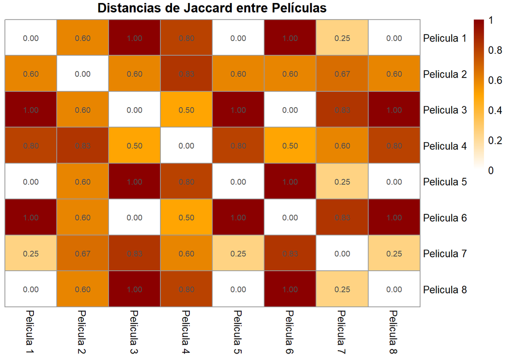

```r
# Visualizar sin clustering (mantener orden original de películas)
pheatmap(as.matrix(dist_jaccard),
         color = colorRampPalette(c("white", "orange", "darkred"))(100),
         main = "Distancias de Jaccard entre Películas",
         display_numbers = TRUE,
         number_format = "%.2f",
         fontsize_number = 8,
         cluster_rows = FALSE,
         cluster_cols = FALSE)  # Sin reordenar para ver índices originales
```

```r
# Encontrar las películas más similares
dist_mat <- as.matrix(dist_jaccard)
diag(dist_mat) <- NA  # Excluir diagonal
min_dist <- which(dist_mat == min(dist_mat, na.rm = TRUE), arr.ind = TRUE)[1,]

cat("\n=== PELÍCULAS MÁS SIMILARES ===\n")
```

```
=== PELÍCULAS MÁS SIMILARES ===
```

```r
cat(sprintf("Las películas más similares son: %s y %s\n",
            rownames(dist_mat)[min_dist[1]],
            rownames(dist_mat)[min_dist[2]]))
```

```
Las películas más similares son: Pelicula 5 y Pelicula 1
```

```r
cat(sprintf("Distancia: %.4f\n", dist_mat[min_dist[1], min_dist[2]]))
```

```
Distancia: 0.0000
```

```r
cat("\nGéneros compartidos:\n")
```

```
Géneros compartidos:
```

```r
print(peliculas[c(min_dist[1], min_dist[2]), ])
```

```
           Accion Comedia Drama Sci_Fi Romance Thriller
Pelicula 5      1       0     0      1       0        1
Pelicula 1      1       0     0      1       0        1
```

# Parte 3: Distancias para Datos Categóricos

## 3.1 Distancia de Hamming

### Ejercicio 3.1: Distancia de Hamming

```r
# Ejemplo: Preferencias de clientes
clientes <- data.frame(
  Color_favorito = c("Rojo", "Azul", "Verde", "Rojo", "Azul"),
  Talla = c("M", "L", "M", "S", "L"),
  Marca_preferida = c("A", "B", "A", "C", "B"),
  Estilo = c("Casual", "Formal", "Deportivo", "Casual", "Formal")
)
rownames(clientes) <- paste("Cliente", 1:5)

cat("=== DATOS CATEGÓRICOS: PREFERENCIAS DE CLIENTES ===\n")
```

```
=== DATOS CATEGÓRICOS: PREFERENCIAS DE CLIENTES ===
```

```r
print(clientes)
```

```
          Color_favorito Talla Marca_preferida    Estilo
Cliente 1           Rojo     M               A    Casual
Cliente 2           Azul     L               B    Formal
Cliente 3          Verde     M               A Deportivo
Cliente 4           Rojo     S               C    Casual
Cliente 5           Azul     L               B    Formal
```

```r
# Función para calcular distancia de Hamming
hamming_distance <- function(x, y) {
  sum(x != y)
}

# Calcular matriz de distancias de Hamming
n <- nrow(clientes)
dist_hamming <- matrix(0, n, n)
for(i in 1:n) {
  for(j in 1:n) {
    dist_hamming[i, j] <- hamming_distance(clientes[i, ], clientes[j, ])
  }
}
rownames(dist_hamming) <- rownames(clientes)
colnames(dist_hamming) <- rownames(clientes)

cat("\n=== MATRIZ DE DISTANCIAS DE HAMMING ===\n")
```

```
=== MATRIZ DE DISTANCIAS DE HAMMING ===
```

```r
print(dist_hamming)
```

```
          Cliente 1 Cliente 2 Cliente 3 Cliente 4 Cliente 5
Cliente 1         0         4         2         2         4
Cliente 2         4         0         4         4         0
Cliente 3         2         4         0         4         4
Cliente 4         2         4         4         0         4
Cliente 5         4         0         4         4         0
```

```r
cat("\nInterpretación:\n")
```

```
Interpretación:
```

```r
cat("- La distancia de Hamming cuenta el número de atributos diferentes\n")
```

```
- La distancia de Hamming cuenta el número de atributos diferentes
```

```r
cat("- Valor máximo posible:", ncol(clientes), "(todas las variables difieren)\n")
```

```
- Valor máximo posible: 4 (todas las variables difieren)
```

```r
cat("- Valor mínimo: 0 (observaciones idénticas)\n")
```

```
- Valor mínimo: 0 (observaciones idénticas)
```

```r
# Normalizar distancias (dividir por número de variables)
dist_hamming_norm <- dist_hamming / ncol(clientes)
cat("\n=== DISTANCIAS DE HAMMING NORMALIZADAS (0-1) ===\n")
```

```
=== DISTANCIAS DE HAMMING NORMALIZADAS (0-1) ===
```

```r
print(round(dist_hamming_norm, 3))
```

```
          Cliente 1 Cliente 2 Cliente 3 Cliente 4 Cliente 5
Cliente 1       0.0         1       0.5       0.5         1
Cliente 2       1.0         0       1.0       1.0         0
Cliente 3       0.5         1       0.0       1.0         1
Cliente 4       0.5         1       1.0       0.0         1
Cliente 5       1.0         0       1.0       1.0         0
```

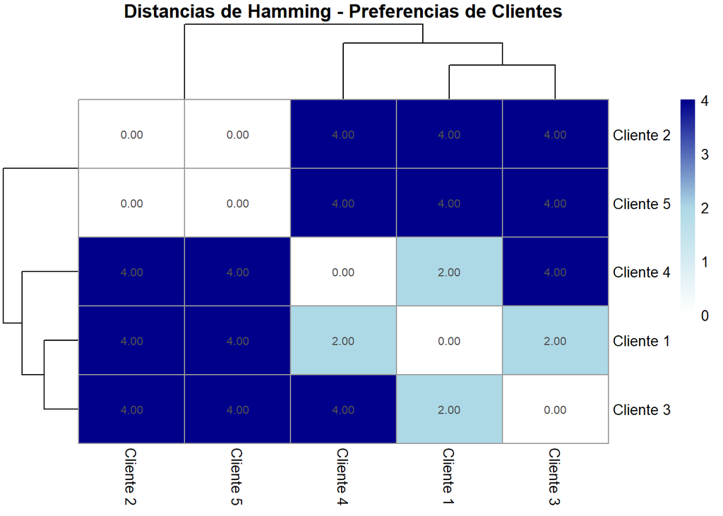

```r
# Visualizar con clustering para agrupar clientes similares
pheatmap(dist_hamming,
         color = colorRampPalette(c("white", "lightblue", "darkblue"))(100),
         main = "Distancias de Hamming - Preferencias de Clientes",
         display_numbers = TRUE,
         cluster_rows = TRUE,
         cluster_cols = TRUE,
         clustering_method = "complete")  # Agrupa clientes con preferencias similares
```

**Pregunta 6**: ¿Qué limitación tiene la distancia de Hamming para variables ordinales?

# Parte 4: Distancias para Datos Mixtos

## 4.1 Distancia de Gower

### Ejercicio 4.1: Distancia de Gower para datos mixtos

**Objetivo**: Calcular distancias cuando tenemos variables de diferentes tipos.

```r
# Crear dataset con variables mixtas
set.seed(123)
datos_mixtos <- data.frame(
  edad = c(25, 30, 25, 45, 50, 28, 35),
  salario = c(30000, 45000, 32000, 65000, 70000, 35000, 50000),
  educacion = factor(c("Grado", "Master", "Grado", "PhD", "PhD", "Master", "Grado"),
                     levels = c("Grado", "Master", "PhD"), ordered = TRUE),
  ciudad = factor(c("Madrid", "Barcelona", "Madrid", "Valencia",
                    "Barcelona", "Madrid", "Valencia")),
  tiene_coche = factor(c("Sí", "No", "Sí", "Sí", "No", "No", "Sí"))
)
rownames(datos_mixtos) <- paste("Persona", 1:7)

cat("=== DATASET CON VARIABLES MIXTAS ===\n")
```

```
=== DATASET CON VARIABLES MIXTAS ===
```

```r
print(datos_mixtos)
```

```
          edad salario educacion    ciudad tiene_coche
Persona 1   25   30000     Grado    Madrid          Sí
Persona 2   30   45000    Master Barcelona          No
Persona 3   25   32000     Grado    Madrid          Sí
Persona 4   45   65000       PhD  Valencia          Sí
Persona 5   50   70000       PhD Barcelona          No
Persona 6   28   35000    Master    Madrid          No
Persona 7   35   50000     Grado  Valencia          Sí
```

```r
cat("\nTipos de variables:\n")
```

```
Tipos de variables:
```

```r
cat("- edad: numérica continua\n")
```

```
- edad: numérica continua
```

```r
cat("- salario: numérica continua\n")
```

```
- salario: numérica continua
```

```r
cat("- educacion: ordinal\n")
```

```
- educacion: ordinal
```

```r
cat("- ciudad: nominal\n")
```

```
- ciudad: nominal
```

```r
cat("- tiene_coche: binaria\n")
```

```
- tiene_coche: binaria
```

```r
# Calcular distancia de Gower
dist_gower <- daisy(datos_mixtos, metric = "gower")

cat("\n=== MATRIZ DE DISTANCIAS DE GOWER ===\n")
```

```
=== MATRIZ DE DISTANCIAS DE GOWER ===
```

```r
print(round(as.matrix(dist_gower), 3))
```

```
          Persona 1 Persona 2 Persona 3 Persona 4 Persona 5 Persona 6 Persona 7
Persona 1     0.000     0.615     0.010     0.735     1.000     0.349     0.380
Persona 2     0.615     0.000     0.605     0.720     0.385     0.266     0.565
Persona 3     0.010     0.605     0.000     0.725     0.990     0.339     0.370
Persona 4     0.735     0.720     0.725     0.000     0.465     0.786     0.355
Persona 5     1.000     0.385     0.990     0.465     0.000     0.651     0.820
Persona 6     0.349     0.266     0.339     0.786     0.651     0.000     0.631
Persona 7     0.380     0.565     0.370     0.355     0.820     0.631     0.000
```

```r
cat("\n=== INTERPRETACIÓN DE GOWER ===\n")
```

```
=== INTERPRETACIÓN DE GOWER ===
```

```r
cat("La distancia de Gower:\n")
```

```
La distancia de Gower:
```

```r
cat("1. Normaliza todas las variables al rango [0,1]\n")
```

```
1. Normaliza todas las variables al rango [0,1]
```

```r
cat("2. Para variables numéricas: d = |x-y| / rango\n")
```

```
2. Para variables numéricas: d = |x-y| / rango
```

```r
cat("3. Para variables categóricas: d = 0 si iguales, 1 si diferentes\n")
```

```
3. Para variables categóricas: d = 0 si iguales, 1 si diferentes
```

```r
cat("4. Para variables ordinales: considera el orden\n")
```

```
4. Para variables ordinales: considera el orden
```

```r
cat("5. Promedia las distancias de todas las variables\n")
```

```
5. Promedia las distancias de todas las variables
```

```r
# Análisis detallado de un par de observaciones
cat("\n=== ANÁLISIS DETALLADO: Persona 1 vs Persona 2 ===\n")
```

```
=== ANÁLISIS DETALLADO: Persona 1 vs Persona 2 ===
```

```r
print(datos_mixtos[1:2, ])
```

```
          edad salario educacion    ciudad tiene_coche
Persona 1   25   30000     Grado    Madrid          Sí
Persona 2   30   45000    Master Barcelona          No
```

```r
cat("\nNOTA IMPORTANTE: El cálculo siguiente es una APROXIMACIÓN educativa.\n")
```

```
NOTA IMPORTANTE: El cálculo siguiente es una APROXIMACIÓN educativa.
```

```r
cat("La función daisy() usa un algoritmo más sofisticado que:\n")
```

```
La función daisy() usa un algoritmo más sofisticado que:
```

```r
cat("- Puede ponderar variables de forma diferente\n")
```

```
- Puede ponderar variables de forma diferente
```

```r
cat("- Maneja valores faltantes (NA) de forma especial\n")
```

```
- Maneja valores faltantes (NA) de forma especial
```

```r
cat("- Para ordinales, considera la estructura de niveles\n\n")
```

```
- Para ordinales, considera la estructura de niveles
```

```r
# Calcular contribución de cada variable (aproximación simplificada)
d_edad <- abs(datos_mixtos$edad[1] - datos_mixtos$edad[2]) /
          (max(datos_mixtos$edad) - min(datos_mixtos$edad))
d_salario <- abs(datos_mixtos$salario[1] - datos_mixtos$salario[2]) /
             (max(datos_mixtos$salario) - min(datos_mixtos$salario))

# Para ordinales, daisy() considera el número de niveles
d_educacion <- ifelse(datos_mixtos$educacion[1] == datos_mixtos$educacion[2], 0,
                      abs(as.numeric(datos_mixtos$educacion[1]) -
                          as.numeric(datos_mixtos$educacion[2])) /
                        (nlevels(datos_mixtos$educacion) - 1))

d_ciudad <- ifelse(datos_mixtos$ciudad[1] == datos_mixtos$ciudad[2], 0, 1)
d_coche <- ifelse(datos_mixtos$tiene_coche[1] == datos_mixtos$tiene_coche[2], 0, 1)

contrib <- data.frame(
  Variable = c("edad", "salario", "educacion", "ciudad", "tiene_coche"),
  Distancia_parcial = round(c(d_edad, d_salario, d_educacion, d_ciudad, d_coche), 3),
  Tipo = c("Numérica", "Numérica", "Ordinal", "Nominal", "Binaria")
)
print(contrib)
```

```
     Variable Distancia_parcial     Tipo
1        edad             0.200 Numérica
2     salario             0.375 Numérica
3   educacion             0.500  Ordinal
4      ciudad             1.000  Nominal
5 tiene_coche             1.000  Binaria
```

```r
cat(sprintf("\nDistancia total (promedio aproximado): %.3f\n", mean(contrib$Distancia_parcial)))
```

```
Distancia total (promedio aproximado): 0.615
```

```r
cat(sprintf("Distancia de Gower real (daisy): %.3f\n", as.matrix(dist_gower)[1, 2]))
```

```
Distancia de Gower real (daisy): 0.615
```

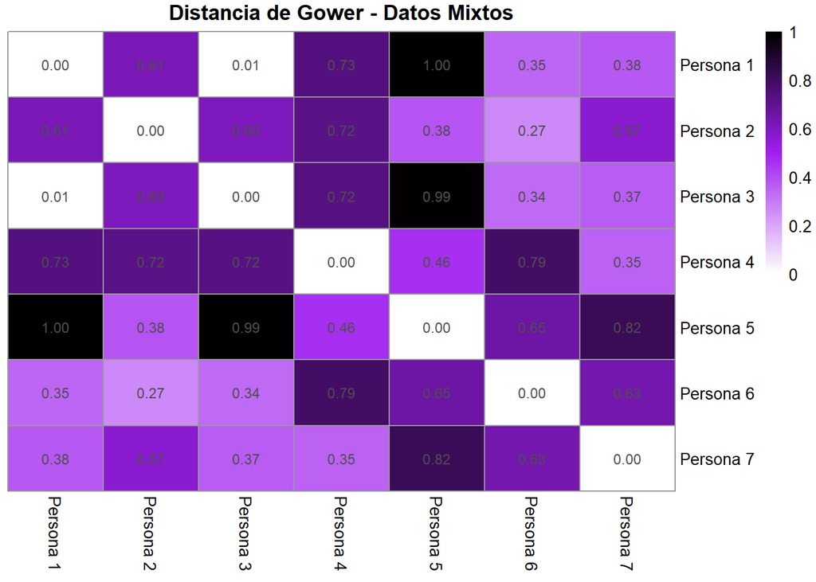

```r
if(abs(mean(contrib$Distancia_parcial) - as.matrix(dist_gower)[1, 2]) > 0.01) {
  cat("\n⚠️  Nota: La diferencia entre ambos valores refleja las diferencias\n")
  cat("   en el tratamiento de variables ordinales y posibles ponderaciones.\n")
}

# Visualizar matriz de distancias sin reordenar (orden original)
pheatmap(as.matrix(dist_gower),
         color = colorRampPalette(c("white", "purple", "black"))(100),
         main = "Distancia de Gower - Datos Mixtos",
         display_numbers = TRUE,
         number_format = "%.2f",
         fontsize_number = 9,
         cluster_rows = FALSE,
         cluster_cols = FALSE)  # Sin clustering para mantener orden original
```

**Pregunta 7**: ¿Por qué es preferible usar Gower en lugar de distancia euclídea para datos mixtos?

### Ejercicio 4.2: Comparación de métodos para datos mixtos

```r
# Comparar diferentes enfoques

# 1. Distancia de Gower (enfoque correcto)
dist_gower <- daisy(datos_mixtos, metric = "gower")

# 2. Convertir todo a numérico (enfoque incorrecto pero común)
cat("=== ⚠️ ADVERTENCIA: ENFOQUE INCORRECTO ===\n")
```

```
=== ⚠️ ADVERTENCIA: ENFOQUE INCORRECTO ===
```

```r
cat("El siguiente código muestra un ERROR COMÚN: convertir variables\n")
```

```
El siguiente código muestra un ERROR COMÚN: convertir variables
```

```r
cat("categóricas a numéricas arbitrariamente.\n\n")
```

```
categóricas a numéricas arbitrariamente.
```

```r
cat("PROBLEMAS de este enfoque:\n")
```

```
PROBLEMAS de este enfoque:
```

```r
cat("1. Introduce relaciones espurias: 'Madrid'=1, 'Barcelona'=2, 'Valencia'=3\n")
```

```
1. Introduce relaciones espurias: 'Madrid'=1, 'Barcelona'=2, 'Valencia'=3
```

```r
cat("   implica que Barcelona está 'entre' Madrid y Valencia (¡no tiene sentido!)\n")
```

```
   implica que Barcelona está 'entre' Madrid y Valencia (¡no tiene sentido!)
```

```r
cat("2. La distancia numérica entre categorías es arbitraria y sin significado\n")
```

```
2. La distancia numérica entre categorías es arbitraria y sin significado
```

```r
cat("3. Variables nominales se tratan como si fueran ordinales o continuas\n")
```

```
3. Variables nominales se tratan como si fueran ordinales o continuas
```

```r
cat("4. Los resultados serán INCORRECTOS y NO INTERPRETABLES\n\n")
```

```
4. Los resultados serán INCORRECTOS y NO INTERPRETABLES
```

```r
cat("¡NUNCA hagas esto en un análisis real!\n\n")
```

```
¡NUNCA hagas esto en un análisis real!
```

```r
datos_numericos <- datos_mixtos
datos_numericos$educacion <- as.numeric(datos_numericos$educacion)
datos_numericos$ciudad <- as.numeric(datos_numericos$ciudad)  # ¡INCORRECTO!
datos_numericos$tiene_coche <- as.numeric(factor(datos_numericos$tiene_coche))
dist_euclidean_naive <- dist(scale(datos_numericos))

cat("=== COMPARACIÓN DE ENFOQUES (Correcto vs Incorrecto) ===\n\n")
```

```
=== COMPARACIÓN DE ENFOQUES (Correcto vs Incorrecto) ===
```

```r
# Comparar rankings de similitud para Persona 1
p1_gower <- as.matrix(dist_gower)[1, -1]
p1_euclidean <- as.matrix(dist_euclidean_naive)[1, -1]

ranking_df <- data.frame(
  Persona = names(p1_gower),
  Dist_Gower = round(p1_gower, 3),
  Rank_Gower = rank(p1_gower),
  Dist_Euclidean_Naive = round(p1_euclidean, 3),
  Rank_Euclidean = rank(p1_euclidean)
)
ranking_df <- ranking_df[order(ranking_df$Rank_Gower), ]

cat("Ranking de similitud con Persona 1:\n")
```

```
Ranking de similitud con Persona 1:
```

```r
print(ranking_df)
```

```
            Persona Dist_Gower Rank_Gower Dist_Euclidean_Naive Rank_Euclidean
Persona 3 Persona 3      0.010          1                0.126              1
Persona 6 Persona 6      0.349          2                2.219              3
Persona 7 Persona 7      0.380          3                2.022              2
Persona 2 Persona 2      0.615          4                2.716              4
Persona 4 Persona 4      0.735          5                3.914              5
Persona 5 Persona 5      1.000          6                4.752              6
```

```r
cat("\n=== CONCLUSIONES IMPORTANTES ===\n")
```

```
=== CONCLUSIONES IMPORTANTES ===
```

```r
cat("1. Los rankings pueden diferir significativamente entre métodos\n")
```

```
1. Los rankings pueden diferir significativamente entre métodos
```

```r
cat("2. Convertir categóricas a numéricas arbitrariamente:\n")
```

```
2. Convertir categóricas a numéricas arbitrariamente:
```

```r
cat("   ✗ Introduce relaciones artificiales sin significado\n")
```

```
   ✗ Introduce relaciones artificiales sin significado
```

```r
cat("   ✗ Produce resultados incorrectos e ininterpretables\n")
```

```
   ✗ Produce resultados incorrectos e ininterpretables
```

```r
cat("   ✗ Viola los supuestos de las distancias numéricas\n")
```

```
   ✗ Viola los supuestos de las distancias numéricas
```

```r
cat("3. Gower maneja correctamente la heterogeneidad de tipos:\n")
```

```
3. Gower maneja correctamente la heterogeneidad de tipos:
```

```r
cat("   ✓ Respeta la naturaleza nominal/ordinal/numérica de cada variable\n")
```

```
   ✓ Respeta la naturaleza nominal/ordinal/numérica de cada variable
```

```r
cat("   ✓ Normaliza adecuadamente para comparabilidad\n")
```

```
   ✓ Normaliza adecuadamente para comparabilidad
```

```r
cat("   ✓ Produce distancias interpretables y válidas\n")
```

```
   ✓ Produce distancias interpretables y válidas
```

```r
cat("4. REGLA DE ORO: Siempre usa el método apropiado para tus datos\n")
```

```
4. REGLA DE ORO: Siempre usa el método apropiado para tus datos
```

## 4.3 Manejo de Valores Faltantes

### Ejercicio 4.3: Distancias con datos incompletos

**Objetivo**: Aprender cómo manejar valores faltantes (NA) al calcular distancias.

```r
cat("=== MANEJO DE VALORES FALTANTES ===\n\n")
```

```
=== MANEJO DE VALORES FALTANTES ===
```

```r
# Crear dataset con valores faltantes
set.seed(123)
datos_na <- data.frame(
  edad = c(25, 30, NA, 45, 50, 28),
  salario = c(30000, NA, 32000, 65000, 70000, 35000),
  horas_trabajo = c(40, 35, 38, NA, 45, 40),
  años_exp = c(2, 5, 3, 15, NA, 4)
)
rownames(datos_na) <- paste("Empleado", 1:6)

cat("Dataset con valores faltantes (NA):\n")
```

```
Dataset con valores faltantes (NA):
```

```r
print(datos_na)
```

```
           edad salario horas_trabajo años_exp
Empleado 1   25   30000            40        2
Empleado 2   30      NA            35        5
Empleado 3   NA   32000            38        3
Empleado 4   45   65000            NA       15
Empleado 5   50   70000            45       NA
Empleado 6   28   35000            40        4
```

```r
cat("\n=== ESTRATEGIAS PARA MANEJAR NAs ===\n\n")
```

```
=== ESTRATEGIAS PARA MANEJAR NAs ===
```

```r
# Estrategia 1: Eliminar observaciones con NA (list-wise deletion)
cat("1. ELIMINACIÓN COMPLETA (list-wise deletion)\n")
```

```
1. ELIMINACIÓN COMPLETA (list-wise deletion)
```

```r
datos_completos <- na.omit(datos_na)
cat("Observaciones restantes:", nrow(datos_completos), "de", nrow(datos_na), "\n")
```

```
Observaciones restantes: 2 de 6
```

```r
cat("⚠️  Pérdida de información:", nrow(datos_na) - nrow(datos_completos), "observaciones\n\n")
```

```
⚠️  Pérdida de información: 4 observaciones
```

```r
if(nrow(datos_completos) > 1) {
  dist_completos <- dist(scale(datos_completos))
  cat("Distancias entre observaciones completas:\n")
  print(round(as.matrix(dist_completos), 2))
}
```

```
Distancias entre observaciones completas:
           Empleado 1 Empleado 6
Empleado 1       0.00       2.83
Empleado 6       2.83       0.00
```

```r
# Estrategia 2: Imputación simple (media)
cat("\n2. IMPUTACIÓN CON LA MEDIA\n")
```

```
2. IMPUTACIÓN CON LA MEDIA
```

```r
datos_imputados <- datos_na
for(col in names(datos_imputados)) {
  media <- mean(datos_imputados[[col]], na.rm = TRUE)
  datos_imputados[[col]][is.na(datos_imputados[[col]])] <- media
}
cat("Datos después de imputación:\n")
```

```
Datos después de imputación:
```

```r
print(round(datos_imputados, 0))
```

```
           edad salario horas_trabajo años_exp
Empleado 1   25   30000            40        2
Empleado 2   30   46400            35        5
Empleado 3   36   32000            38        3
Empleado 4   45   65000            40       15
Empleado 5   50   70000            45        6
Empleado 6   28   35000            40        4
```

```r
dist_imputados <- dist(scale(datos_imputados))
cat("\nDistancias con imputación:\n")
```

```
Distancias con imputación:
```

```r
print(round(as.matrix(dist_imputados), 2))
```

```
           Empleado 1 Empleado 2 Empleado 3 Empleado 4 Empleado 5 Empleado 6
Empleado 1       0.00       1.97       1.25       3.97       3.82       0.59
Empleado 2       1.97       0.00       1.42       3.15       3.91       1.69
Empleado 3       1.25       1.42       0.00       3.35       3.44       1.02
Empleado 4       3.97       3.15       3.35       0.00       2.63       3.37
Empleado 5       3.82       3.91       3.44       2.63       0.00       3.38
Empleado 6       0.59       1.69       1.02       3.37       3.38       0.00
```

```r
# Estrategia 3: Distancia de Gower (maneja NAs automáticamente)
cat("\n3. DISTANCIA DE GOWER (maneja NAs automáticamente)\n")
```

```
3. DISTANCIA DE GOWER (maneja NAs automáticamente)
```

```r
cat("Gower ajusta el cálculo excluyendo pares de variables con NA\n\n")
```

```
Gower ajusta el cálculo excluyendo pares de variables con NA
```

```r
dist_gower_na <- daisy(datos_na, metric = "gower")
cat("Distancias de Gower con NAs:\n")
```

```
Distancias de Gower con NAs:
```

```r
print(round(as.matrix(dist_gower_na), 3))
```

```
           Empleado 1 Empleado 2 Empleado 3 Empleado 4 Empleado 5 Empleado 6
Empleado 1      0.000      0.310      0.109      0.892      0.833      0.100
Empleado 2      0.310      0.000      0.227      0.685      0.900      0.219
Empleado 3      0.109      0.227      0.000      0.874      0.825      0.117
Empleado 4      0.892      0.685      0.874      0.000      0.162      0.759
Empleado 5      0.833      0.900      0.825      0.162      0.000      0.752
Empleado 6      0.100      0.219      0.117      0.759      0.752      0.000
```

```r
cat("\n=== CÓMO GOWER MANEJA NAs ===\n")
```

```
=== CÓMO GOWER MANEJA NAs ===
```

```r
cat("Para cada par de observaciones (i, j):\n")
```

```
Para cada par de observaciones (i, j):
```

```r
cat("1. Calcula distancia solo para variables presentes en AMBAS\n")
```

```
1. Calcula distancia solo para variables presentes en AMBAS
```

```r
cat("2. Si variable es NA en i o j, la excluye del promedio\n")
```

```
2. Si variable es NA en i o j, la excluye del promedio
```

```r
cat("3. Promedia sobre las variables disponibles\n")
```

```
3. Promedia sobre las variables disponibles
```

```r
cat("4. Si NO hay variables en común → distancia = NA\n\n")
```

```
4. Si NO hay variables en común → distancia = NA
```

```r
# Ejemplo detallado
cat("Ejemplo: Empleado 1 vs Empleado 3\n")
```

```
Ejemplo: Empleado 1 vs Empleado 3
```

```r
cat("Empleado 1: edad=25, salario=30000, horas=40, exp=2\n")
```

```
Empleado 1: edad=25, salario=30000, horas=40, exp=2
```

```r
cat("Empleado 3: edad=NA, salario=32000, horas=38, exp=3\n")
```

```
Empleado 3: edad=NA, salario=32000, horas=38, exp=3
```

```r
cat("Variables usadas: salario, horas_trabajo, años_exp (3 de 4)\n")
```

```
Variables usadas: salario, horas_trabajo, años_exp (3 de 4)
```

```r
cat(sprintf("Distancia Gower: %.3f\n\n", as.matrix(dist_gower_na)[1, 3]))
```

```
Distancia Gower: 0.109
```

```r
# Comparación visual
cat("=== COMPARACIÓN DE ESTRATEGIAS ===\n\n")
```

```
=== COMPARACIÓN DE ESTRATEGIAS ===
```

```r
comparison_df <- data.frame(
  Estrategia = c("Eliminación completa", "Imputación media", "Gower con NAs"),
  Observaciones = c(nrow(datos_completos), nrow(datos_na), nrow(datos_na)),
  Ventajas = c(
    "Simple, sin sesgo si NA es aleatorio",
    "Mantiene todas las observaciones",
    "No asume valores, usa info disponible"
  ),
  Desventajas = c(
    "Pérdida de información, reduce muestra",
    "Introduce sesgo, subestima varianza",
    "Complejidad computacional"
  )
)
print(comparison_df)
```

```
            Estrategia Observaciones                              Ventajas
1 Eliminación completa             2  Simple, sin sesgo si NA es aleatorio
2     Imputación media             6      Mantiene todas las observaciones
3        Gower con NAs             6 No asume valores, usa info disponible
                             Desventajas
1 Pérdida de información, reduce muestra
2    Introduce sesgo, subestima varianza
3              Complejidad computacional
```

```r
cat("\n=== RECOMENDACIONES ===\n")
```

```
=== RECOMENDACIONES ===
```

```r
cat("1. Si < 5% NAs aleatorios → Eliminación completa\n")
```

```
1. Si < 5% NAs aleatorios → Eliminación completa
```

```r
cat("2. Si NAs no aleatorios → Imputación sofisticada (kNN, MICE)\n")
```

```
2. Si NAs no aleatorios → Imputación sofisticada (kNN, MICE)
```

```r
cat("3. Para datos mixtos con NAs → Gower\n")
```

```
3. Para datos mixtos con NAs → Gower
```

```r
cat("4. Para alta dimensionalidad → Métodos especializados\n")
```

```
4. Para alta dimensionalidad → Métodos especializados
```

```r
cat("5. NUNCA ignorar NAs sin justificación\n")
```

```
5. NUNCA ignorar NAs sin justificación
```

**Pregunta 9**: ¿Qué problemas puede causar la imputación con la media en el cálculo de distancias?

## 4.4 Maldición de la Dimensionalidad

### Ejercicio 4.4: Efecto de la dimensionalidad en distancias

**Objetivo**: Entender cómo la alta dimensionalidad afecta a las distancias.

```r
cat("=== MALDICIÓN DE LA DIMENSIONALIDAD ===\n\n")
```

```
=== MALDICIÓN DE LA DIMENSIONALIDAD ===
```

```r
set.seed(123)

# Generar datos aleatorios en diferentes dimensiones
dimensiones <- c(2, 10, 50, 100, 500, 1000)
resultados <- list()

for(d in dimensiones) {
  # Generar 100 puntos aleatorios en d dimensiones
  datos_d <- matrix(rnorm(100 * d), nrow = 100, ncol = d)

  # Calcular todas las distancias
  dist_matrix <- as.matrix(dist(datos_d))

  # Extraer distancias (sin diagonal)
  distancias <- dist_matrix[upper.tri(dist_matrix)]

  # Estadísticas
  resultados[[as.character(d)]] <- data.frame(
    Dimensiones = d,
    Media = mean(distancias),
    SD = sd(distancias),
    Min = min(distancias),
    Max = max(distancias),
    CV = sd(distancias) / mean(distancias)  # Coef. variación
  )
}

resultados_df <- do.call(rbind, resultados)
rownames(resultados_df) <- NULL

cat("=== ESTADÍSTICAS DE DISTANCIAS POR DIMENSIÓN ===\n")
```

```
=== ESTADÍSTICAS DE DISTANCIAS POR DIMENSIÓN ===
```

```r
print(round(resultados_df, 4))
```

```
  Dimensiones   Media     SD     Min     Max     CV
1           2  1.6637 0.8768  0.0287  5.7251 0.5270
2          10  4.3937 0.9973  1.7603  8.7836 0.2270
3          50  9.9258 0.9504  5.6646 13.2929 0.0958
4         100 14.1431 0.9774 10.8049 18.0553 0.0691
5         500 31.7023 0.9603 27.8012 34.9750 0.0303
6        1000 44.7514 0.9781 41.0473 48.3267 0.0219
```

```r
cat("\n=== OBSERVACIONES CLAVE ===\n")
```

```
=== OBSERVACIONES CLAVE ===
```

```r
cat("1. Media de distancias AUMENTA con dimensiones\n")
```

```
1. Media de distancias AUMENTA con dimensiones
```

```r
cat("2. Coeficiente de variación (CV) DISMINUYE\n")
```

```
2. Coeficiente de variación (CV) DISMINUYE
```

```r
cat("3. En alta dimensión, ¡todos los puntos están lejos y equidistantes!\n\n")
```

```
3. En alta dimensión, ¡todos los puntos están lejos y equidistantes!
```

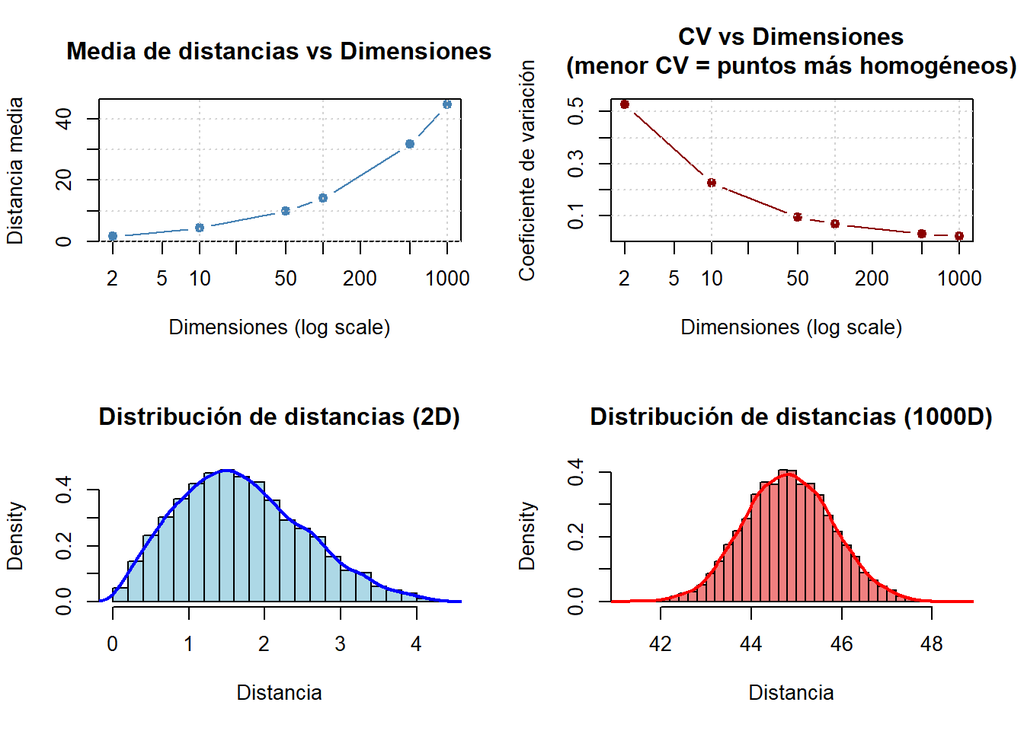

```r
# Visualizar
par(mfrow = c(2, 2))

# Gráfico 1: Media de distancias
plot(resultados_df$Dimensiones, resultados_df$Media,
     type = "b", pch = 19, col = "steelblue",
     log = "x",
     xlab = "Dimensiones (log scale)", ylab = "Distancia media",
     main = "Media de distancias vs Dimensiones")
grid()

# Gráfico 2: Coeficiente de variación
plot(resultados_df$Dimensiones, resultados_df$CV,
     type = "b", pch = 19, col = "darkred",
     log = "x",
     xlab = "Dimensiones (log scale)", ylab = "Coeficiente de variación",
     main = "CV vs Dimensiones\n(menor CV = puntos más homogéneos)")
grid()

# Gráfico 3: Distribución en 2D
datos_2d <- matrix(rnorm(100 * 2), nrow = 100, ncol = 2)
dist_2d <- as.matrix(dist(datos_2d))
hist(dist_2d[upper.tri(dist_2d)], breaks = 30, col = "lightblue",
     main = "Distribución de distancias (2D)",
     xlab = "Distancia", freq = FALSE)
lines(density(dist_2d[upper.tri(dist_2d)]), col = "blue", lwd = 2)

# Gráfico 4: Distribución en 1000D
datos_1000d <- matrix(rnorm(100 * 1000), nrow = 100, ncol = 1000)
dist_1000d <- as.matrix(dist(datos_1000d))
hist(dist_1000d[upper.tri(dist_1000d)], breaks = 30, col = "lightcoral",
     main = "Distribución de distancias (1000D)",
     xlab = "Distancia", freq = FALSE)
lines(density(dist_1000d[upper.tri(dist_1000d)]), col = "red", lwd = 2)
```

```r
par(mfrow = c(1, 1))

cat("\n=== ¿POR QUÉ OCURRE ESTO? ===\n")
```

```
=== ¿POR QUÉ OCURRE ESTO? ===
```

```r
cat("En alta dimensión:\n")
```

```
En alta dimensión:
```

```r
cat("1. El volumen del espacio crece exponencialmente\n")
```

```
1. El volumen del espacio crece exponencialmente
```

```r
cat("2. Los datos se vuelven DISPERSOS (sparse)\n")
```

```
2. Los datos se vuelven DISPERSOS (sparse)
```

```r
cat("3. La mayoría del volumen está en las 'esquinas' del hipervolumen\n")
```

```
3. La mayoría del volumen está en las 'esquinas' del hipervolumen
```

```r
cat("4. La distancia al punto más cercano ≈ distancia al más lejano\n")
```

```
4. La distancia al punto más cercano ≈ distancia al más lejano
```

```r
cat("5. El concepto de 'vecindario' pierde significado\n\n")
```

```
5. El concepto de 'vecindario' pierde significado
```

```r
cat("=== CONSECUENCIAS PARA MACHINE LEARNING ===\n")
```

```
=== CONSECUENCIAS PARA MACHINE LEARNING ===
```

```r
cat("✗ K-NN se vuelve ineficaz (todos son 'vecinos')\n")
```

```
✗ K-NN se vuelve ineficaz (todos son 'vecinos')
```

```r
cat("✗ Clustering puede fallar (no hay clusters claros)\n")
```

```
✗ Clustering puede fallar (no hay clusters claros)
```

```r
cat("✗ Se requieren MUCHOS más datos para el mismo nivel de densidad\n")
```

```
✗ Se requieren MUCHOS más datos para el mismo nivel de densidad
```

```r
cat("✗ Distancia Euclídea pierde poder discriminativo\n\n")
```

```
✗ Distancia Euclídea pierde poder discriminativo
```

```r
cat("=== SOLUCIONES ===\n")
```

```
=== SOLUCIONES ===
```

```r
cat("✓ Reducción de dimensionalidad (PCA, t-SNE, UMAP)\n")
```

```
✓ Reducción de dimensionalidad (PCA, t-SNE, UMAP)
```

```r
cat("✓ Selección de características relevantes\n")
```

```
✓ Selección de características relevantes
```

```r
cat("✓ Usar distancias alternativas (Manhattan, Coseno)\n")
```

```
✓ Usar distancias alternativas (Manhattan, Coseno)
```

```r
cat("✓ Métodos específicos para alta dimensión\n")
```

```
✓ Métodos específicos para alta dimensión
```

```r
cat("✓ Regularización en modelos\n")
```

```
✓ Regularización en modelos
```

**Pregunta 10**: ¿Por qué la distancia Manhattan puede ser preferible a la Euclídea en alta dimensionalidad?

# Parte 5: Ejercicios Integradores

## 5.1 Análisis Comparativo de Distancias

### Ejercicio 5.1: ¿Qué distancia elegir?

```r
cat("=== GUÍA DE DECISIÓN: ¿QUÉ DISTANCIA USAR? ===\n\n")
```

```
=== GUÍA DE DECISIÓN: ¿QUÉ DISTANCIA USAR? ===
```

```r
decision_tree <- "
TIPO DE DATOS
│
├─ TODOS CONTINUOS
│  │
│  ├─ Escalas similares
│  │  └─ Euclidea, Manhattan, Minkowski
│  │
│  ├─ Escalas diferentes
│  │  └─ Estandarizar primero, luego Euclídea
│  │
│  ├─ Presencia de outliers
│  │  └─ Manhattan o Chebyshev (más robustas)
│  │
│  └─ Alta dimensionalidad
│     └─ Manhattan o coseno (evitar maldición dimensionalidad)
│
├─ TODOS BINARIOS
│  │
│  ├─ Ausencia no informativa (ej: presencia de palabras)
│  │  └─ Jaccard
│  │
│  └─ Ausencia informativa (ej: síntomas médicos)
│     └─ Simple Matching
│
├─ TODOS CATEGÓRICOS
│  │
│  ├─ Nominales
│  │  └─ Hamming
│  │
│  └─ Ordinales
│     └─ Convertir a rangos, usar métrica numérica
│
└─ MIXTOS (continuos + categóricos + binarios)
   └─ Gower
"

cat(decision_tree)
```

```
TIPO DE DATOS
│
├─ TODOS CONTINUOS
│  │
│  ├─ Escalas similares
│  │  └─ Euclidea, Manhattan, Minkowski
│  │
│  ├─ Escalas diferentes
│  │  └─ Estandarizar primero, luego Euclídea
│  │
│  ├─ Presencia de outliers
│  │  └─ Manhattan o Chebyshev (más robustas)
│  │
│  └─ Alta dimensionalidad
│     └─ Manhattan o coseno (evitar maldición dimensionalidad)
│
├─ TODOS BINARIOS
│  │
│  ├─ Ausencia no informativa (ej: presencia de palabras)
│  │  └─ Jaccard
│  │
│  └─ Ausencia informativa (ej: síntomas médicos)
│     └─ Simple Matching
│
├─ TODOS CATEGÓRICOS
│  │
│  ├─ Nominales
│  │  └─ Hamming
│  │
│  └─ Ordinales
│     └─ Convertir a rangos, usar métrica numérica
│
└─ MIXTOS (continuos + categóricos + binarios)
   └─ Gower
```

```r
# Ejemplo de aplicación
cat("\n\n=== CASOS DE USO ===\n\n")
```

```
=== CASOS DE USO ===
```

```r
casos <- data.frame(
  Contexto = c(
    "Análisis de clientes (edad, ingresos, género, ciudad)",
    "Clasificación de documentos (frecuencia de palabras)",
    "Diagnóstico médico (síntomas presentes/ausentes)",
    "Análisis de genes (expresión génica)",
    "Recomendación de productos (características mixtas)"
  ),
  Tipo_Datos = c("Mixtos", "Continuos (alta dim)", "Binarios",
                 "Continuos", "Mixtos"),
  Distancia_Recomendada = c("Gower", "Coseno o Manhattan",
                            "Jaccard", "Euclídea (estandarizada)", "Gower")
)

print(casos)
```

```
                                               Contexto           Tipo_Datos
1 Análisis de clientes (edad, ingresos, género, ciudad)               Mixtos
2  Clasificación de documentos (frecuencia de palabras) Continuos (alta dim)
3      Diagnóstico médico (síntomas presentes/ausentes)             Binarios
4                  Análisis de genes (expresión génica)            Continuos
5   Recomendación de productos (características mixtas)               Mixtos
     Distancia_Recomendada
1                    Gower
2       Coseno o Manhattan
3                  Jaccard
4 Euclídea (estandarizada)
5                    Gower
```

## 5.2 Proyecto Final: Análisis Completo

### Ejercicio 5.2: Análisis de dataset mtcars

```r
# Cargar y explorar datos
data(mtcars)
cat("=== DATASET: MTCARS ===\n")
```

```
=== DATASET: MTCARS ===
```

```r
cat("Características de 32 automóviles\n\n")
```

```
Características de 32 automóviles
```

```r
str(mtcars)
```

```
'data.frame':   32 obs. of  11 variables:
 $ mpg : num  21 21 22.8 21.4 18.7 18.1 14.3 24.4 22.8 19.2 ...
 $ cyl : num  6 6 4 6 8 6 8 4 4 6 ...
 $ disp: num  160 160 108 258 360 ...
 $ hp  : num  110 110 93 110 175 105 245 62 95 123 ...
 $ drat: num  3.9 3.9 3.85 3.08 3.15 2.76 3.21 3.69 3.92 3.92 ...
 $ wt  : num  2.62 2.88 2.32 3.21 3.44 ...
 $ qsec: num  16.5 17 18.6 19.4 17 ...
 $ vs  : num  0 0 1 1 0 1 0 1 1 1 ...
 $ am  : num  1 1 1 0 0 0 0 0 0 0 ...
 $ gear: num  4 4 4 3 3 3 3 4 4 4 ...
 $ carb: num  4 4 1 1 2 1 4 2 2 4 ...
```

```r
# Seleccionar variables relevantes
# Continuos: mpg, disp, hp, wt, qsec
# Discretas (trataremos como categóricas): cyl, vs, am, gear, carb
mtcars_mixed <- mtcars
mtcars_mixed$cyl <- factor(mtcars_mixed$cyl)
mtcars_mixed$vs <- factor(mtcars_mixed$vs)
mtcars_mixed$am <- factor(mtcars_mixed$am)
mtcars_mixed$gear <- factor(mtcars_mixed$gear)
mtcars_mixed$carb <- factor(mtcars_mixed$carb)

# 1. Distancia Euclídea (solo variables continuas)
vars_continuas <- c("mpg", "disp", "hp", "wt", "qsec", "drat")
dist_euclidean_std <- dist(scale(mtcars[, vars_continuas]))

# 2. Distancia de Gower (todas las variables)
dist_gower_all <- daisy(mtcars_mixed, metric = "gower")

cat("\n=== COMPARACIÓN DE MÉTODOS ===\n")
```

```
=== COMPARACIÓN DE MÉTODOS ===
```

```r
# Seleccionar 5 coches emblemáticos
coches_emblematicos <- c("Mazda RX4", "Datsun 710", "Hornet 4 Drive",
                         "Merc 240D", "Porsche 914-2")
idx <- which(rownames(mtcars) %in% coches_emblematicos)

cat("\nCoches seleccionados:\n")
```

```
Coches seleccionados:
```

```r
print(mtcars[idx, c("mpg", "cyl", "hp", "wt")])
```

```
                mpg cyl  hp    wt
Mazda RX4      21.0   6 110 2.620
Datsun 710     22.8   4  93 2.320
Hornet 4 Drive 21.4   6 110 3.215
Merc 240D      24.4   4  62 3.190
Porsche 914-2  26.0   4  91 2.140
```

```r
# Matriz de distancias Euclídea
cat("\n--- Distancia Euclídea (solo variables continuas) ---\n")
```

```
--- Distancia Euclídea (solo variables continuas) ---
```

```r
dist_euc_sub <- as.matrix(dist_euclidean_std)[idx, idx]
rownames(dist_euc_sub) <- coches_emblematicos
colnames(dist_euc_sub) <- coches_emblematicos
print(round(dist_euc_sub, 2))
```

```
               Mazda RX4 Datsun 710 Hornet 4 Drive Merc 240D Porsche 914-2
Mazda RX4           0.00       1.37           2.48      2.29          1.45
Datsun 710          1.37       0.00           2.17      1.36          1.63
Hornet 4 Drive      2.48       2.17           0.00      1.72          3.44
Merc 240D           2.29       1.36           1.72      0.00          2.60
Porsche 914-2       1.45       1.63           3.44      2.60          0.00
```

```r
# Matriz de distancias Gower
cat("\n--- Distancia de Gower (todas las variables) ---\n")
```

```
--- Distancia de Gower (todas las variables) ---
```

```r
dist_gow_sub <- as.matrix(dist_gower_all)[idx, idx]
rownames(dist_gow_sub) <- coches_emblematicos
colnames(dist_gow_sub) <- coches_emblematicos
print(round(dist_gow_sub, 2))
```

```
               Mazda RX4 Datsun 710 Hornet 4 Drive Merc 240D Porsche 914-2
Mazda RX4           0.00       0.33           0.47      0.46          0.34
Datsun 710          0.33       0.00           0.38      0.25          0.34
Hornet 4 Drive      0.47       0.38           0.00      0.36          0.62
Merc 240D           0.46       0.25           0.36      0.00          0.39
Porsche 914-2       0.34       0.34           0.62      0.39          0.00
```

```r
# Visualizar ambas
par(mfrow = c(1, 2))
pheatmap(dist_euc_sub,
         main = "Euclídea (continuas)",
         display_numbers = TRUE,
         number_format = "%.2f",
         fontsize_number = 8,
         cluster_rows = FALSE,
         cluster_cols = FALSE,
         silent = TRUE)

pheatmap(dist_gow_sub,
         main = "Gower (todas)",
         display_numbers = TRUE,
         number_format = "%.2f",
         fontsize_number = 8,
         cluster_rows = FALSE,
         cluster_cols = FALSE,
         silent = TRUE)
par(mfrow = c(1, 1))

cat("\n=== CONCLUSIONES DEL ANÁLISIS ===\n")
```

```
=== CONCLUSIONES DEL ANÁLISIS ===
```

```r
cat("1. Las distancias Euclídea y Gower pueden dar resultados diferentes\n")
```

```
1. Las distancias Euclídea y Gower pueden dar resultados diferentes
```

```r
cat("2. Gower incorpora información de variables categóricas (cyl, vs, am, etc.)\n")
```

```
2. Gower incorpora información de variables categóricas (cyl, vs, am, etc.)
```

```r
cat("3. La elección de la distancia afecta a los resultados de clustering\n")
```

```
3. La elección de la distancia afecta a los resultados de clustering
```

```r
cat("4. Es crucial entender las propiedades de tus datos antes de elegir\n")
```

```
4. Es crucial entender las propiedades de tus datos antes de elegir
```

**Pregunta 8**: ¿Qué método prefieres para este dataset y por qué?

# Recursos Adicionales

## Librerías útiles en R

- `proxy`: Implementa 50+ medidas de distancia y similitud
- `cluster`: Contiene `daisy()` para distancia de Gower
- `gower`: Implementación eficiente de distancia de Gower
- `philentropy`: Distancias y divergencias para distribuciones
- `text2vec`: Distancias especializadas para text mining

## Lecturas recomendadas

### Libros

- Gan, G., Ma, C., & Wu, J. (2020). *Data Clustering: Theory, Algorithms, and Applications* (2nd ed.). Society for Industrial and Applied Mathematics (SIAM). [ISBN: 978-1-611976-31-0]
- Deza, M. M., & Deza, E. (2009). *Encyclopedia of Distances* (4th ed.). Springer. https://doi.org/10.1007/978-3-662-52844-0
- Aggarwal, C. C., Hinneburg, A., & Keim, D. A. (2001). “On the Surprising Behavior of Distance Metrics in High Dimensional Space”. In: *Database Theory — ICDT 2001*. Lecture Notes in Computer Science, vol 1973. Springer. https://doi.org/10.1007/3-540-44503-X_27

### Artículos

- Boriah, S., Chandola, V., & Kumar, V. (2008). “Similarity Measures for Categorical Data: A Comparative Evaluation”. In: *Proceedings of the 2008 SIAM International Conference on Data Mining*, pp. 243-254. https://doi.org/10.1137/1.9781611972788.22
- Gower, J. C. (1971). “A General Coefficient of Similarity and Some of Its Properties”. *Biometrics*, 27(4), 857-871. https://doi.org/10.2307/2528823
- Hamming, R. W. (1950). “Error Detecting and Error Correcting Codes”. *The Bell System Technical Journal*, 29(2), 147-160. https://doi.org/10.1002/j.1538-7305.1950.tb00463.x

### Recursos online

- Documentación de R package `proxy`: https://CRAN.R-project.org/package=proxy
- Documentación de R package `cluster`: https://CRAN.R-project.org/package=cluster

## Preguntas de reflexión final

1. ¿Por qué la distancia euclídea puede no ser apropiada en alta dimensionalidad? *Pista: Piensa en la maldición de la dimensionalidad y el coeficiente de variación.*
2. ¿Qué problemas puede causar calcular distancias sin estandarizar? *Pista: Considera variables con diferentes escalas y unidades.*
3. ¿Cuándo preferirías Manhattan sobre Euclídea? *Pista: Outliers, interpretabilidad, alta dimensionalidad.*
4. ¿Cómo manejarías valores faltantes al calcular distancias? *Pista: Depende del porcentaje de NAs y del mecanismo de ausencia.*
5. ¿Por qué la distancia coseno es invariante a la escala? *Pista: Solo mide el ángulo, no la magnitud.*
6. ¿Qué distancia usarías para comparar perfiles de compradores en e-commerce? *Pista: Datos mixtos (edad, género, categorías de productos, gasto).*

**Fin del Laboratorio 4.1**